# Langasek_cs559_project

Patty Langasek

August 6, 2019

```r
library(skimr)
library(dplyr) # for proper filtring capabilities
```

```r
library(tidyr)
library(ggplot2) # for proper plotting capabilities
```

## Data: Wine Variety Classification

Data was collected from Kaggle at https://www.kaggle.com/brynja/wineuci

```r
wine.header <- c('varietal', 'alcohol', 'mal_acid', 'ash', 'alc_ash', 'Mg', 'tot_phenols',
                 'flavanoids', 'nonflav_phenols', 'proanthocyanins', 'color_int', 'hue',
                 'od_dil', 'proline')

wine.data <- read.csv('wine.data', header = FALSE, sep = ',')

colnames(wine.data) <- wine.header
wine.data <- wine.data[c(2, 3, 4, 5, 6, 7, 8, 9, 10, 11, 12, 13, 14, 1)]
wine.data$varietal <- as.factor(wine.data$varietal)
```

## EDA

```r
skim(wine.data)
```

```
## Skim summary statistics
##  n obs: 178
##  n variables: 14
##
## ── Variable type:factor ────────────────────────────────────────────────────────────────────────────────────
##  variable missing complete   n n_unique                 top_counts ordered
##  varietal       0      178 178        3 2: 71, 1: 59, 3: 48, NA: 0   FALSE
##
## ── Variable type:integer ───────────────────────────────────────────────────────────────────────────────────
##  variable missing complete   n   mean     sd  p0   p25   p50 p75 p100
##        Mg       0      178 178  99.74  14.28  70  88    98   107  162
##   proline       0      178 178 746.89 314.91 278 500.5 673.5 985 1680
##      hist
##  ▂▇▇▅▂▁▁▁
##  ▅▇▆▃▃▃▁▁
##
## ── Variable type:numeric ───────────────────────────────────────────────────────────────────────────────────
##         variable missing complete   n  mean   sd    p0   p25   p50   p75
##          alc_ash       0      178 178 19.49 3.34 10.6  17.2  19.5  21.5
##          alcohol       0      178 178 13    0.81 11.03 12.36 13.05 13.68
##              ash       0      178 178  2.37 0.27  1.36  2.21  2.36  2.56
##        color_int       0      178 178  5.06 2.32  1.28  3.22  4.69  6.2
##       flavanoids       0      178 178  2.03 1     0.34  1.2   2.13  2.88
##              hue       0      178 178  0.96 0.23  0.48  0.78  0.96  1.12
##         mal_acid       0      178 178  2.34 1.12  0.74  1.6   1.87  3.08
##  nonflav_phenols       0      178 178  0.36 0.12  0.13  0.27  0.34  0.44
##           od_dil       0      178 178  2.61 0.71  1.27  1.94  2.78  3.17
##  proanthocyanins       0      178 178  1.59 0.57  0.41  1.25  1.56  1.95
##      tot_phenols       0      178 178  2.3  0.63  0.98  1.74  2.35  2.8
##   p100     hist
##  30    ▁▁▆▇▆▂▁▁
##  14.83 ▁▃▇▆▇▇▅▁
##   3.23 ▁▁▂▆▇▆▁▁
##  13    ▅▇▇▅▃▂▁▁
##   5.08 ▇▅▆▇▇▂▁▁
##   1.71 ▃▅▆▇▆▂▁▁
##   5.8  ▃▇▂▂▂▁▁▁
##   0.66 ▂▆▇▅▅▃▂▂
##   4    ▅▅▃▃▇▇▆▁
##   3.58 ▂▅▇▇▃▁▁▁
##   3.88 ▁▇▆▅▇▇▂▁
```

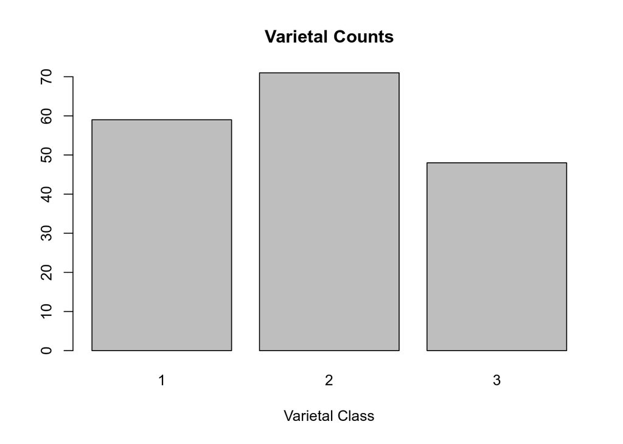

```r
barplot(table(wine.data$varietal), main="Varietal Counts", xlab="Varietal Class")
```

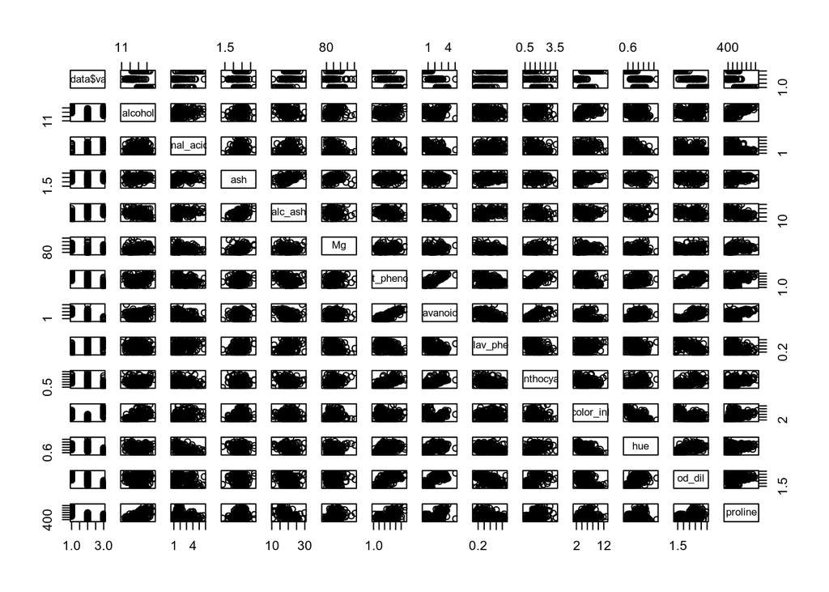

```r
pairs(formula = wine.data$varietal ~ ., data = wine.data)
```

```r
cor(wine.data[1:13])
```

```
##                     alcohol    mal_acid          ash     alc_ash
## alcohol          1.00000000  0.09439694  0.211544596 -0.31023514
## mal_acid         0.09439694  1.00000000  0.164045470  0.28850040
## ash              0.21154460  0.16404547  1.000000000  0.44336719
## alc_ash         -0.31023514  0.28850040  0.443367187  1.00000000
## Mg               0.27079823 -0.05457510  0.286586691 -0.08333309
## tot_phenols      0.28910112 -0.33516700  0.128979538 -0.32111332
## flavanoids       0.23681493 -0.41100659  0.115077279 -0.35136986
## nonflav_phenols -0.15592947  0.29297713  0.186230446  0.36192172
## proanthocyanins  0.13669791 -0.22074619  0.009651935 -0.19732684
## color_int        0.54636420  0.24898534  0.258887259  0.01873198
## hue             -0.07174720 -0.56129569 -0.074666889 -0.27395522
## od_dil           0.07234319 -0.36871043  0.003911231 -0.27676855
## proline          0.64372004 -0.19201056  0.223626264 -0.44059693
##                          Mg tot_phenols flavanoids nonflav_phenols
## alcohol          0.27079823  0.28910112  0.2368149      -0.1559295
## mal_acid        -0.05457510 -0.33516700 -0.4110066       0.2929771
## ash              0.28658669  0.12897954  0.1150773       0.1862304
## alc_ash         -0.08333309 -0.32111332 -0.3513699       0.3619217
## Mg               1.00000000  0.21440123  0.1957838      -0.2562940
## tot_phenols      0.21440123  1.00000000  0.8645635      -0.4499353
## flavanoids       0.19578377  0.86456350  1.0000000      -0.5378996
## nonflav_phenols -0.25629405 -0.44993530 -0.5378996       1.0000000
## proanthocyanins  0.23644061  0.61241308  0.6526918      -0.3658451
## color_int        0.19995001 -0.05513642 -0.1723794       0.1390570
## hue              0.05539820  0.43368134  0.5434786      -0.2626396
## od_dil           0.06600394  0.69994936  0.7871939      -0.5032696
## proline          0.39335085  0.49811488  0.4941931      -0.3113852
##                 proanthocyanins   color_int         hue       od_dil
## alcohol             0.136697912  0.54636420 -0.07174720  0.072343187
## mal_acid           -0.220746187  0.24898534 -0.56129569 -0.368710428
## ash                 0.009651935  0.25888726 -0.07466689  0.003911231
## alc_ash            -0.197326836  0.01873198 -0.27395522 -0.276768549
## Mg                  0.236440610  0.19995001  0.05539820  0.066003936
## tot_phenols         0.612413084 -0.05513642  0.43368134  0.699949365
## flavanoids          0.652691769 -0.17237940  0.54347857  0.787193902
## nonflav_phenols    -0.365845099  0.13905701 -0.26263963 -0.503269596
## proanthocyanins     1.000000000 -0.02524993  0.29554425  0.519067096
## color_int          -0.025249931  1.00000000 -0.52181319 -0.428814942
## hue                 0.295544253 -0.52181319  1.00000000  0.565468293
## od_dil              0.519067096 -0.42881494  0.56546829  1.000000000
## proline             0.330416700  0.31610011  0.23618345  0.312761075
##                    proline
## alcohol          0.6437200
## mal_acid        -0.1920106
## ash              0.2236263
## alc_ash         -0.4405969
## Mg               0.3933508
## tot_phenols      0.4981149
## flavanoids       0.4941931
## nonflav_phenols -0.3113852
## proanthocyanins  0.3304167
## color_int        0.3161001
## hue              0.2361834
## od_dil           0.3127611
## proline          1.0000000
```

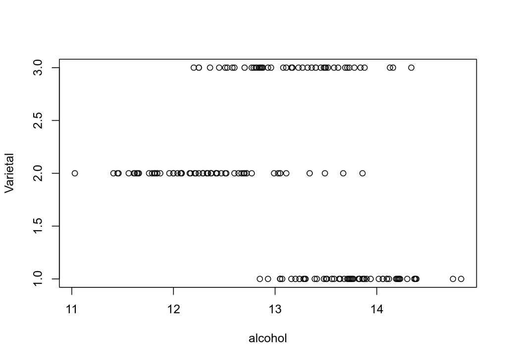

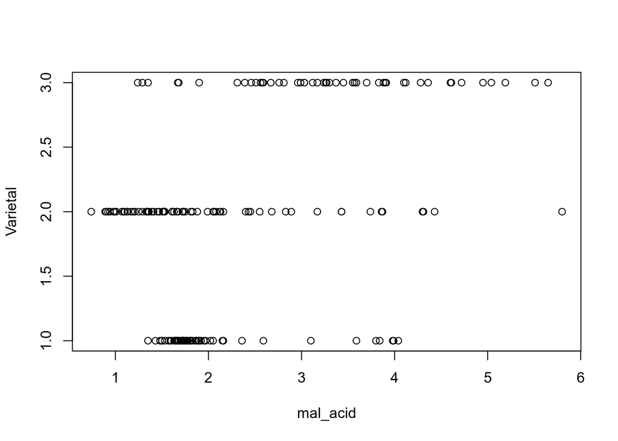

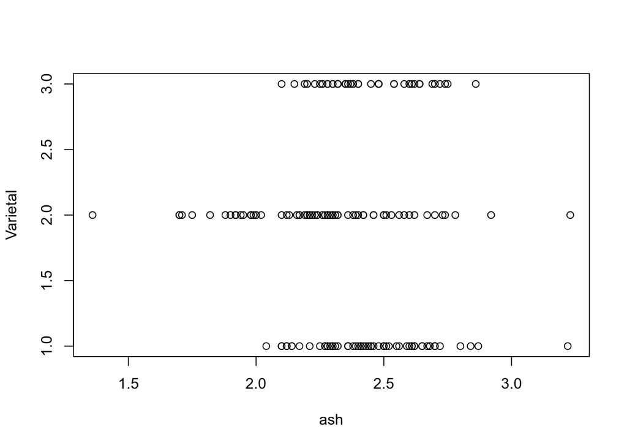

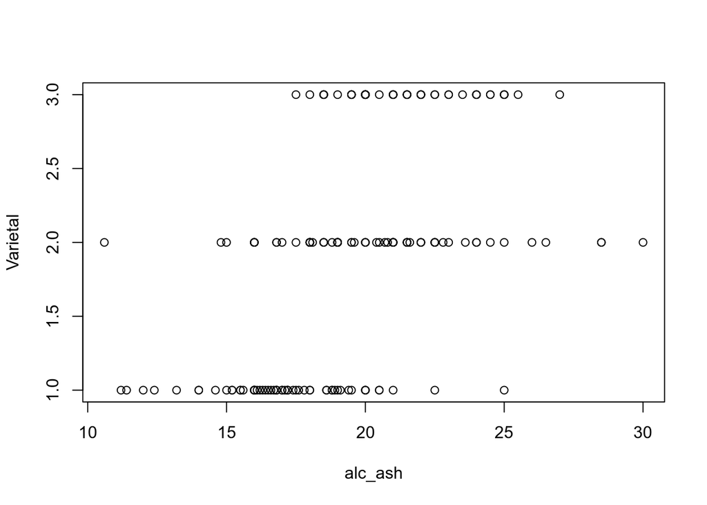

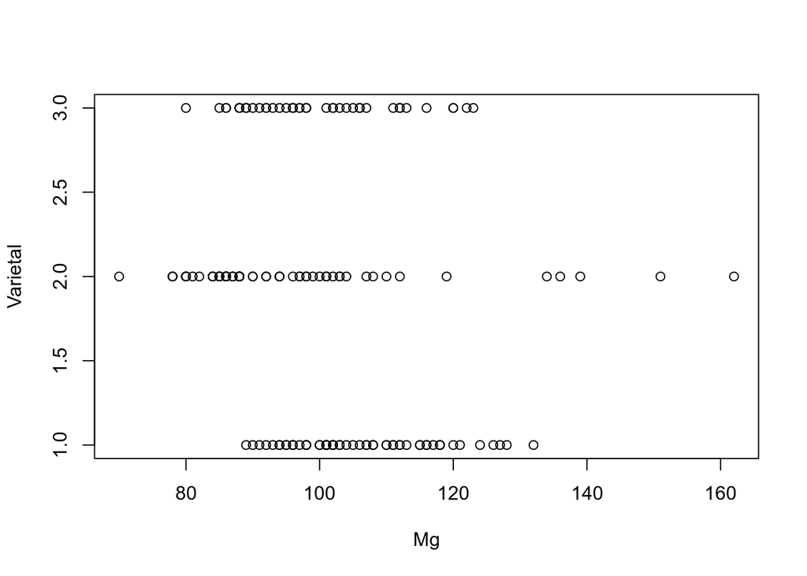

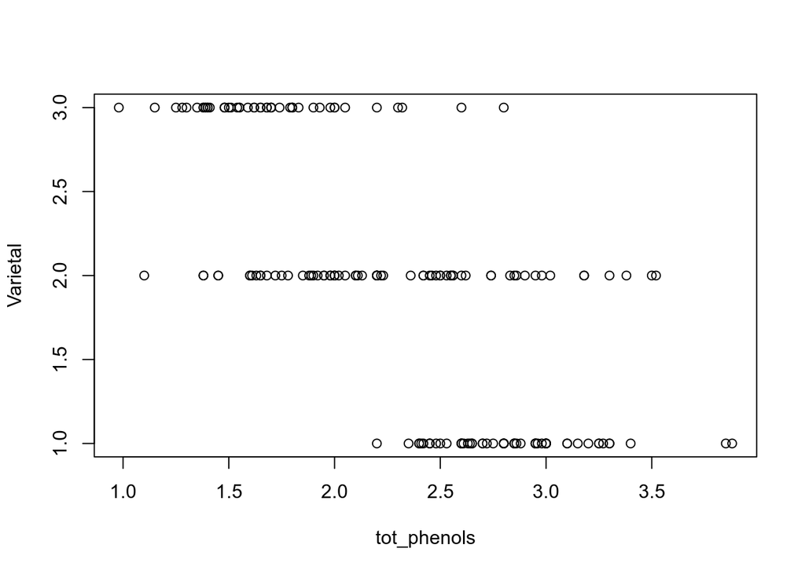

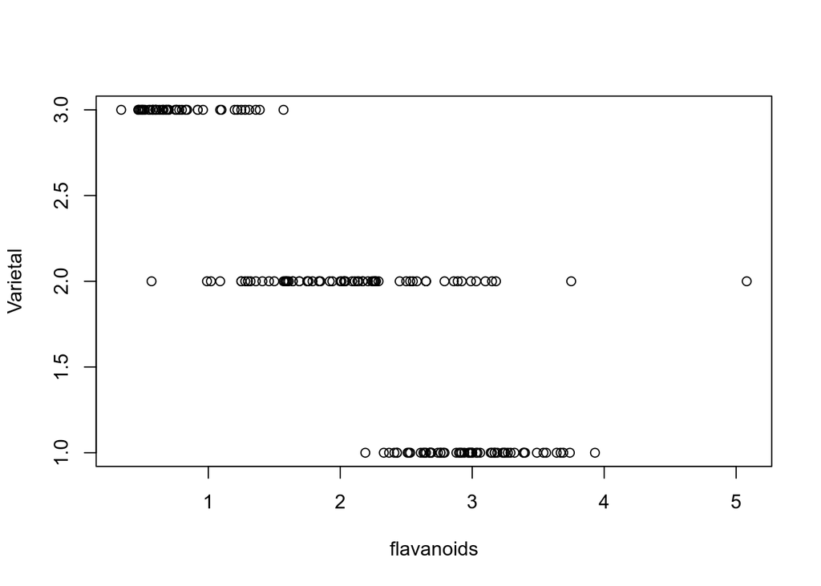

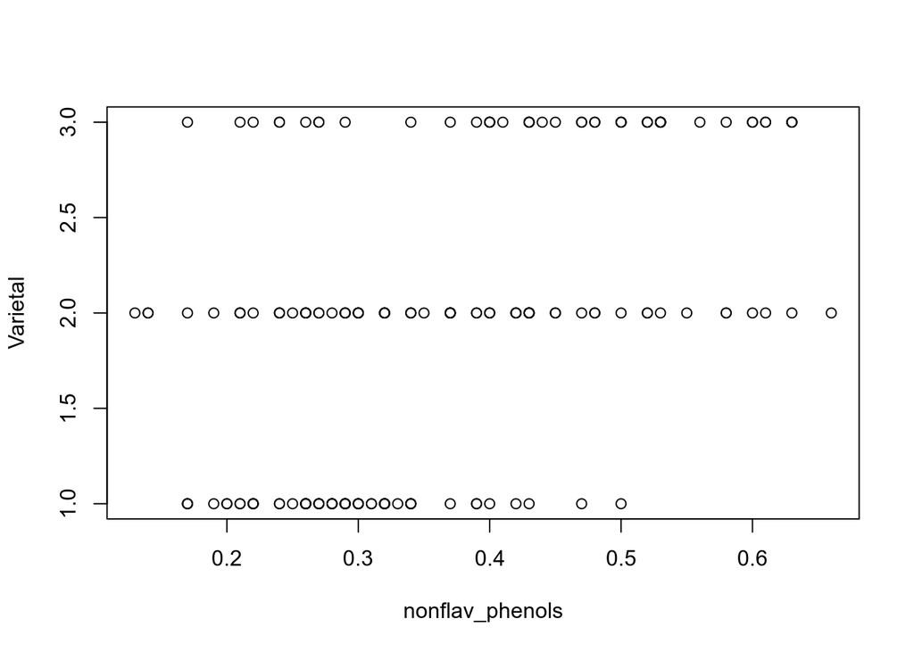

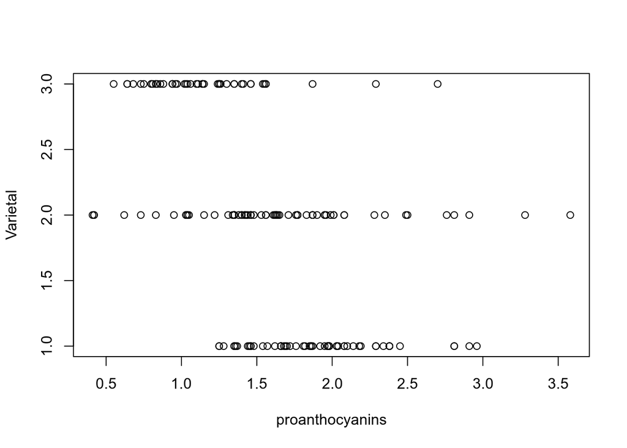

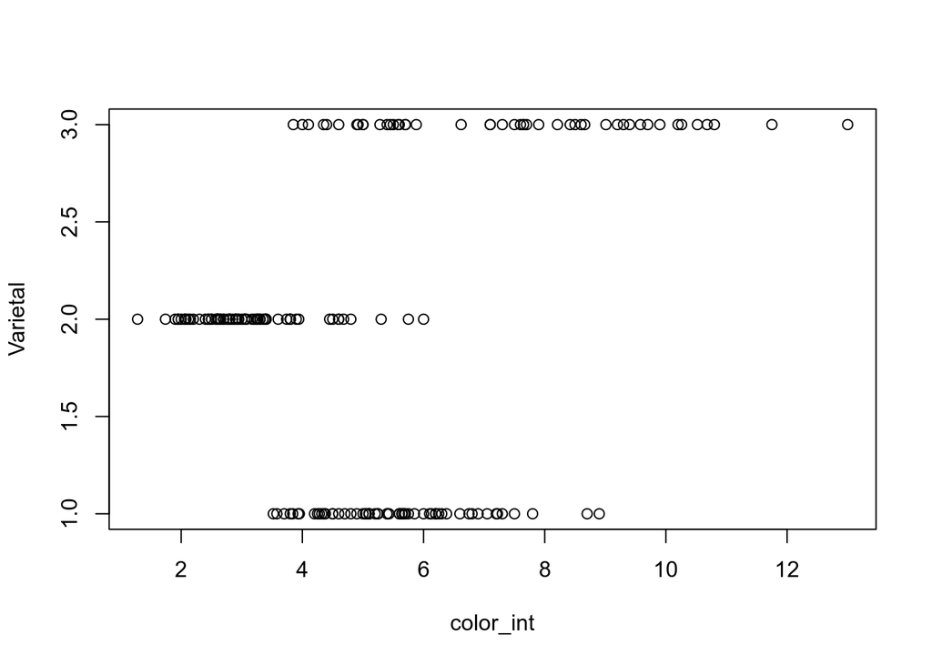

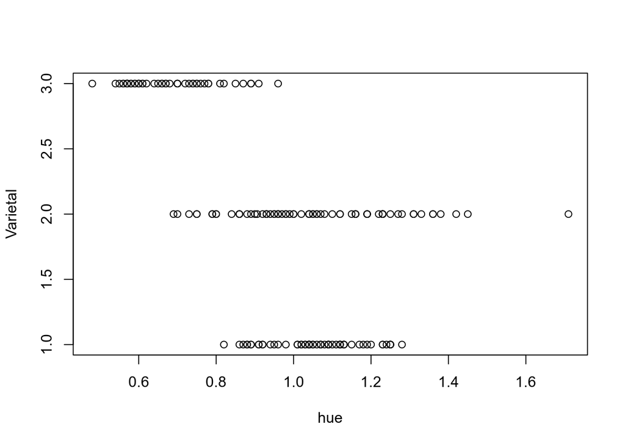

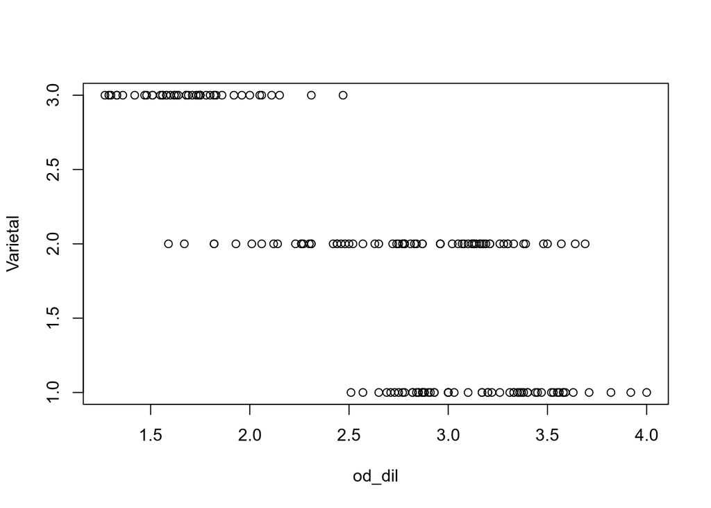

[1 more figures not shown]

```r
loop.vector <- 1:13

for (i in loop.vector) {
  x <- wine.data[,i]
  plot(x = x, y = wine.data$varietal, xlab = colnames(wine.data[i]), ylab = "Varietal")
}
```

Flavanoids very clearly splits varietals 1 and 3 from each other, creating 2 sets of binary splits from there. With absolutely no overlap between the two classes and a reasonably large buffer between them, this may be useful going foward as a manual split.

Just as a cursory glance, it’d be nice to see how the variables are shaped based on varietal class. Using filter() from the library, dplyr because it actually handles the dataframe as I expect it to.

```r
wine.1 <- filter(wine.data, wine.data$varietal == '1')
wine.2 <- filter(wine.data, wine.data$varietal == '2')
wine.3 <- filter(wine.data, wine.data$varietal == '3')
```

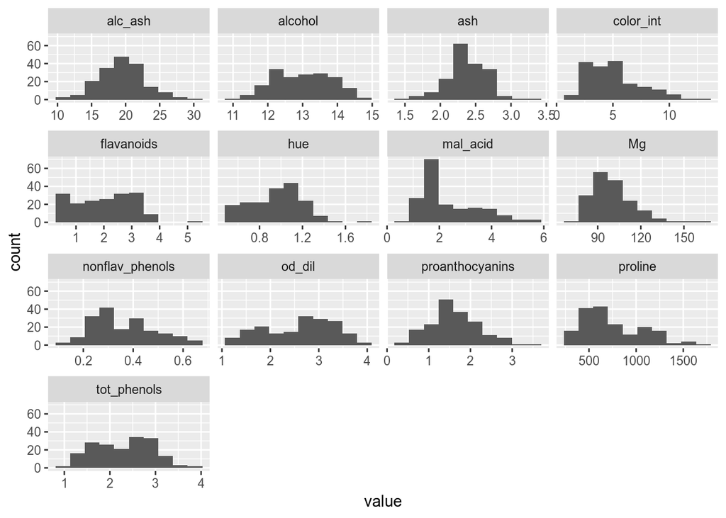

```r
ggplot(gather(wine.data[1:13]), aes(value), groupName=wine.data[14]) +
  geom_histogram(bins = 10) +
  facet_wrap(~key, scales = 'free_x')
```

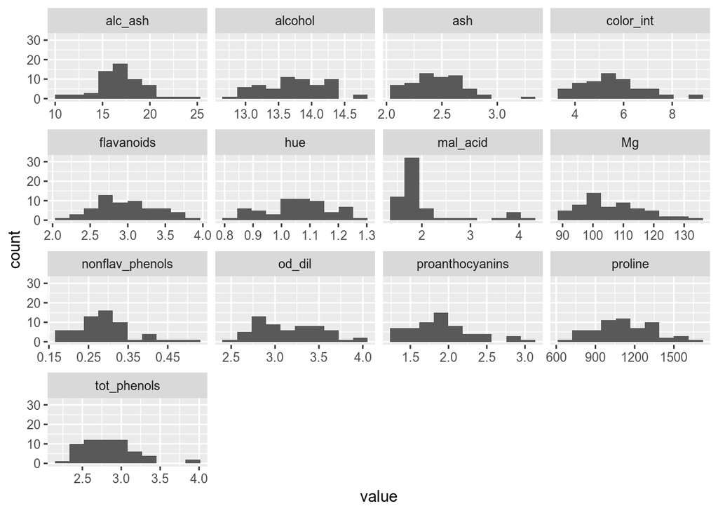

```r
ggplot(gather(wine.1[1:13]), aes(value), groupName=wine.data[14]) +
  geom_histogram(bins = 10) +
  facet_wrap(~key, scales = 'free_x')
```

```r
skim(wine.1)
```

```
## Skim summary statistics
##  n obs: 59
##  n variables: 14
##
## ── Variable type:factor ────────────────────────────────────────────────────────────────────────────────────
##  variable missing complete  n n_unique               top_counts ordered
##  varietal       0       59 59        1 1: 59, 2: 0, 3: 0, NA: 0   FALSE
##
## ── Variable type:integer ───────────────────────────────────────────────────────────────────────────────────
##  variable missing complete  n    mean     sd  p0   p25  p50  p75 p100
##        Mg       0       59 59  106.34  10.5   89  98    104  114  132
##   proline       0       59 59 1115.71 221.52 680 987.5 1095 1280 1680
##      hist
##  ▃▅▇▅▃▅▁▂
##  ▃▃▆▇▇▂▃▁
##
## ── Variable type:numeric ───────────────────────────────────────────────────────────────────────────────────
##         variable missing complete  n  mean   sd    p0   p25   p50   p75
##          alc_ash       0       59 59 17.04 2.55 11.2  16    16.8  18.7
##          alcohol       0       59 59 13.74 0.46 12.85 13.4  13.75 14.1
##              ash       0       59 59  2.46 0.23  2.04  2.29  2.44  2.62
##        color_int       0       59 59  5.53 1.24  3.52  4.55  5.4   6.22
##       flavanoids       0       59 59  2.98 0.4   2.19  2.68  2.98  3.25
##              hue       0       59 59  1.06 0.12  0.82  0.99  1.07  1.13
##         mal_acid       0       59 59  2.01 0.69  1.35  1.67  1.77  1.94
##  nonflav_phenols       0       59 59  0.29 0.07  0.17  0.26  0.29  0.32
##           od_dil       0       59 59  3.16 0.36  2.51  2.87  3.17  3.42
##  proanthocyanins       0       59 59  1.9  0.41  1.25  1.64  1.87  2.09
##      tot_phenols       0       59 59  2.84 0.34  2.2   2.6   2.8   3
##   p100     hist
##  25    ▂▂▆▇▃▂▁▁
##  14.83 ▅▅▅▇▅▆▂▁
##   3.22 ▅▆▇▆▅▂▁▁
##   8.9  ▅▇▇▇▃▃▁▁
##   3.93 ▂▃▇▇▅▃▃▁
##   1.28 ▂▅▂▇▆▆▂▅
##   4.04 ▅▇▁▁▁▁▁▂
##   0.5  ▃▃▇▅▂▁▁▁
##   4    ▂▇▅▃▆▅▁▂
##   2.96 ▆▅▆▇▂▂▁▂
##   3.88 ▂▆▆▇▃▂▁▁
```

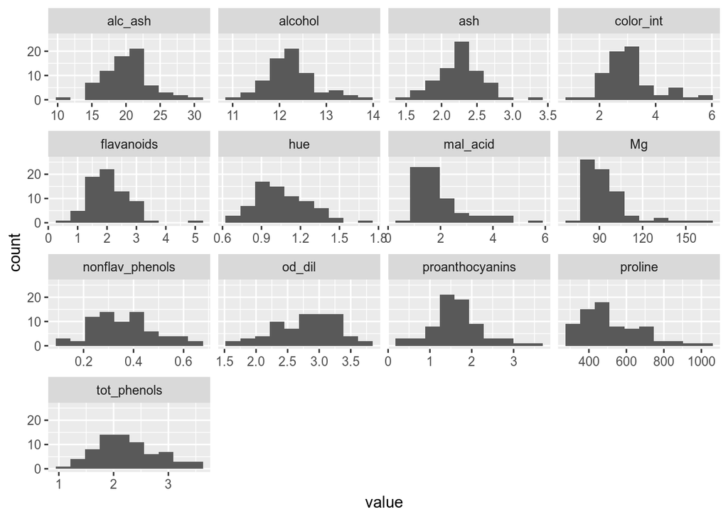

```r
ggplot(gather(wine.2[1:13]), aes(value), groupName=wine.data[14]) +
  geom_histogram(bins = 10) +
  facet_wrap(~key, scales = 'free_x')
```

```r
skim(wine.2)
```

```
## Skim summary statistics
##  n obs: 71
##  n variables: 14
##
## ── Variable type:factor ────────────────────────────────────────────────────────────────────────────────────
##  variable missing complete  n n_unique               top_counts ordered
##  varietal       0       71 71        1 2: 71, 1: 0, 3: 0, NA: 0   FALSE
##
## ── Variable type:integer ───────────────────────────────────────────────────────────────────────────────────
##  variable missing complete  n   mean     sd  p0   p25 p50   p75 p100
##        Mg       0       71 71  94.55  16.75  70  85.5  88  99.5  162
##   proline       0       71 71 519.51 157.21 278 406.5 495 625    985
##      hist
##  ▂▇▅▁▁▁▁▁
##  ▅▇▇▅▃▁▁▁
##
## ── Variable type:numeric ───────────────────────────────────────────────────────────────────────────────────
##         variable missing complete  n  mean   sd    p0   p25   p50   p75
##          alc_ash       0       71 71 20.24 3.35 10.6  18    20    22
##          alcohol       0       71 71 12.28 0.54 11.03 11.91 12.29 12.52
##              ash       0       71 71  2.24 0.32  1.36  2     2.24  2.42
##        color_int       0       71 71  3.09 0.92  1.28  2.54  2.9   3.4
##       flavanoids       0       71 71  2.08 0.71  0.57  1.6   2.03  2.48
##              hue       0       71 71  1.06 0.2   0.69  0.93  1.04  1.21
##         mal_acid       0       71 71  1.93 1.02  0.74  1.27  1.61  2.15
##  nonflav_phenols       0       71 71  0.36 0.12  0.13  0.27  0.37  0.43
##           od_dil       0       71 71  2.79 0.5   1.59  2.44  2.83  3.16
##  proanthocyanins       0       71 71  1.63 0.6   0.41  1.35  1.61  1.89
##      tot_phenols       0       71 71  2.26 0.55  1.1   1.9   2.2   2.56
##   p100     hist
##  30    ▁▁▃▇▇▂▁▁
##  13.86 ▁▃▇▇▃▂▁▁
##   3.23 ▁▂▅▇▆▃▁▁
##   6    ▁▅▇▅▂▂▁▁
##   5.08 ▁▆▇▃▂▁▁▁
##   1.71 ▃▅▇▅▅▂▁▁
##   5.8  ▇▇▃▁▂▁▁▁
##   0.66 ▃▇▇▇▇▃▂▂
##   3.69 ▂▂▅▅▇▇▆▂
##   3.58 ▂▃▇▇▂▁▁▁
##   3.52 ▂▅▇▇▇▃▂▂
```

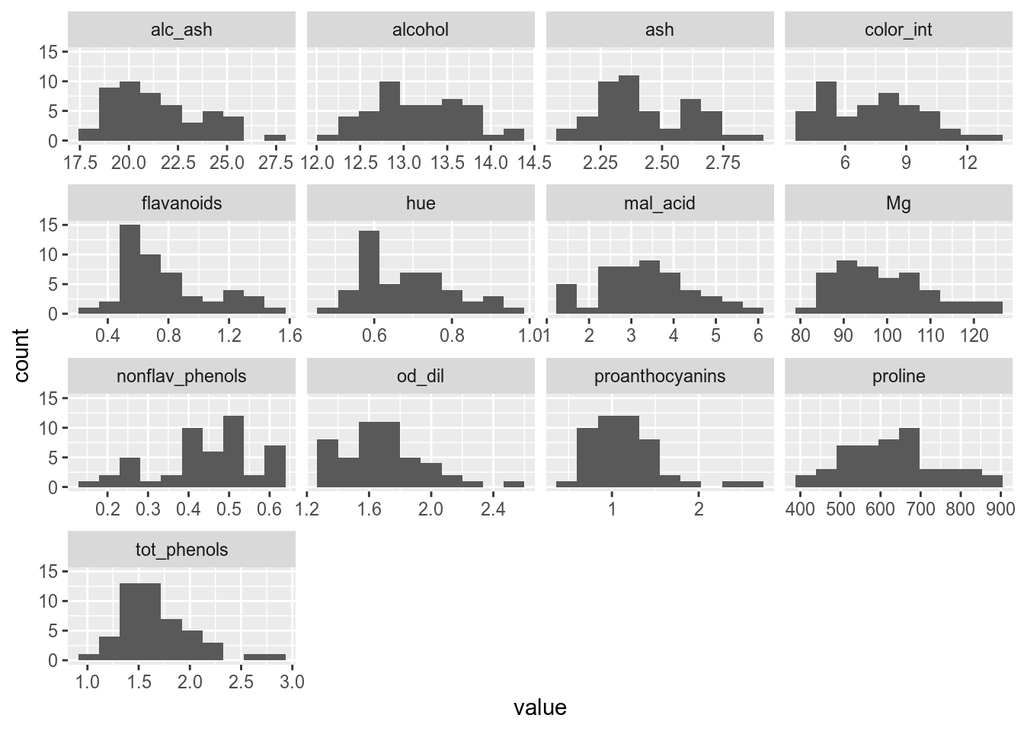

```r
ggplot(gather(wine.3[1:13]), aes(value), groupName=wine.data[14]) +
  geom_histogram(bins = 10) +
  facet_wrap(~key, scales = 'free_x')
```

```r
skim(wine.3)
```

```
## Skim summary statistics
##  n obs: 48
##  n variables: 14
##
## ── Variable type:factor ────────────────────────────────────────────────────────────────────────────────────
##  variable missing complete  n n_unique               top_counts ordered
##  varietal       0       48 48        1 3: 48, 1: 0, 2: 0, NA: 0   FALSE
##
## ── Variable type:integer ───────────────────────────────────────────────────────────────────────────────────
##  variable missing complete  n   mean     sd  p0    p25   p50 p75 p100
##        Mg       0       48 48  99.31  10.89  80  89.75  97   106  123
##   proline       0       48 48 629.9  115.1  415 545    627.5 695  880
##      hist
##  ▂▇▇▅▆▃▂▃
##  ▂▇▅▇▇▃▁▃
##
## ── Variable type:numeric ───────────────────────────────────────────────────────────────────────────────────
##         variable missing complete  n  mean   sd    p0   p25   p50   p75
##          alc_ash       0       48 48 21.42 2.26 17.5  20    21    23
##          alcohol       0       48 48 13.15 0.53 12.2  12.8  13.16 13.5
##              ash       0       48 48  2.44 0.18  2.1   2.3   2.38  2.6
##        color_int       0       48 48  7.4  2.31  3.85  5.44  7.55  9.22
##       flavanoids       0       48 48  0.78 0.29  0.34  0.58  0.69  0.92
##              hue       0       48 48  0.68 0.11  0.48  0.59  0.67  0.75
##         mal_acid       0       48 48  3.33 1.09  1.24  2.59  3.26  3.96
##  nonflav_phenols       0       48 48  0.45 0.12  0.17  0.4   0.47  0.53
##           od_dil       0       48 48  1.68 0.27  1.27  1.51  1.66  1.82
##  proanthocyanins       0       48 48  1.15 0.41  0.55  0.85  1.1   1.35
##      tot_phenols       0       48 48  1.68 0.36  0.98  1.41  1.64  1.81
##   p100     hist
##  27    ▃▃▇▅▂▃▂▁
##  14.34 ▃▃▇▅▆▅▂▂
##   2.86 ▂▅▇▃▁▃▃▁
##  13    ▆▇▂▆▅▅▂▁
##   1.57 ▃▇▇▃▂▂▂▁
##   0.96 ▁▇▂▅▅▁▂▁
##   5.65 ▃▂▆▇▆▃▃▂
##   0.63 ▂▃▂▅▆▆▇▆
##   2.47 ▆▆▇▇▂▃▁▁
##   2.7  ▅▇▇▅▁▁▁▁
##   2.8  ▁▇▇▇▃▂▁▁
```

### Step 3: Classification

Looking at the histograms, it would appear that there are definitely some parameters that can easily divide the data, with the best sort between varietals 1 and 3.

ASSUMPTION: Yes, I’m assuming a linear relationship between the varietal and the 13 predictor variables, and I’m assuming each predictor variable has its own weight.

## Data Split and Algorithm Learning

### Data Split

The main split, and the final test dataset will not be touched until I’m ready to fully test the classifier. All of my cross validation training will be done with the full.train set.

```r
set.seed(1701)

wine.split.smpl <- sample(seq_len(nrow(wine.data)), size = 138)

wine.full.train <- wine.data[wine.split.smpl, ]
wine.final.test <- wine.data[-wine.split.smpl, ]
```

### Algorithm Plan

Looking at the data, there is one obvious split point between varietals 1 and 3, so, dividing

1. Split the data into the cross-validation sets:
- 120 in training set
- 18 in test set
2. Create a decision tree for the training cv set.
- Need 3 leaves
- For first split, check flavanoids. <= 1.88, must be either 3 or 2; >= 1.89, must be either 1 or 2. (To get this, the difference between p0 of Varietal 1 and p100 of Varietal 3 is 0.62. I chose the midpoint of this difference as a buffer that will still clearly separate the varietals.) Because this is an obvious split discovered by the EDA, I’ll assume this split is a given.
- Calculate proportions for each remaining branch.
- On each branch, for each remaining parameter, formulate a question to divide all observations into 1 varietal class.
- Calculate impurity for each division.
- Choose lowest impurity and store for that branch division.
3. Run decision tree for test set.
4. Calculate the accuracy of the test set decision tree.
5. Repeat process 4 more times.

```r
cv_temp <- sample.int(n = 138, size = 120, replace = FALSE)
cv_temp_train <- wine.full.train[cv_temp, ]
cv_temp_test <- wine.full.train[-cv_temp, ]
```

```r
# testing filter of flavanoids by checking impurity.

branch.1a <- filter(cv_temp_train, flavanoids >= 1.89) # Varietal 1 or 2
branch.2a <- filter(cv_temp_train, flavanoids <= 1.88) # Varietal 2 or 3

(p_1.branch.1a <- nrow(filter(branch.1a, varietal == 1)) / nrow(branch.1a))
```

```
## [1] 0.5909091
```

```r
(p_2.branch.1a <- nrow(filter(branch.1a, varietal == 2)) / nrow(branch.1a))
```

```
## [1] 0.4090909
```

```r
(p_2.branch.1a <- nrow(filter(branch.1a, varietal == 3)) / nrow(branch.1a))
```

```
## [1] 0
```

```r
(p_1.branch.2a <- nrow(filter(branch.2a, varietal == 1)) / nrow(branch.2a))
```

```
## [1] 0
```

```r
(p_2.branch.2a <- nrow(filter(branch.2a, varietal == 2)) / nrow(branch.2a))
```

```
## [1] 0.3888889
```

```r
(p_3.branch.2a <- nrow(filter(branch.2a, varietal == 3)) / nrow(branch.2a))
```

```
## [1] 0.6111111
```

```r
# further flavanoid filtering
leaf.1a_2 <- filter(branch.1a, flavanoids < 2.19) # MUST be Varietal 2
branch.1b <- filter(branch.1a, flavanoids >= 2.19) # Varietal 1 or 2, but with better purity.

(p_1.leaf.1a <- nrow(filter(leaf.1a_2, varietal == 1)) / nrow(leaf.1a_2))
```

```
## [1] 0
```

```r
(p_2.leaf.1a <- nrow(filter(leaf.1a_2, varietal == 2)) / nrow(leaf.1a_2))
```

```
## [1] 1
```

```r
(p_1.branch.1b <- nrow(filter(branch.1b, varietal == 1)) / nrow(branch.1b))
```

```
## [1] 0.6842105
```

```r
(p_2.branch.1b <- nrow(filter(branch.1b, varietal == 2)) / nrow(branch.1b))
```

```
## [1] 0.3157895
```

```r
leaf.2a_2 <- filter(branch.2a, flavanoids > 1.57) # MUST be Varietal 2
branch.2b <- filter(branch.2a, flavanoids <= 1.57) # Varietal 2 or 3, but with better purity.

(p_2.leaf.2a <- nrow(filter(leaf.2a_2, varietal == 2)) / nrow(leaf.2a_2))
```

```
## [1] 1
```

```r
(p_3.leaf.2a <- nrow(filter(leaf.2a_2, varietal == 3)) / nrow(leaf.2a_2))
```

```
## [1] 0
```

```r
(p_2.branch.2b <- nrow(filter(branch.2b, varietal == 2)) / nrow(branch.2b))
```

```
## [1] 0.195122
```

```r
(p_3.branch.2b <- nrow(filter(branch.2b, varietal == 3)) / nrow(branch.2b))
```

```
## [1] 0.804878
```

Now to functionalize it!

```r
# flavanoid filter function

flav_filt <- function(X){
  branch.1a <- filter(X, flavanoids >= 1.89) # Varietal 1 or 2
  leaf.1b <- filter(branch.1a, flavanoids < 2.19) # MUST be Varietal 2
  branch.1b <- filter(branch.1a, flavanoids >= 2.19) # Varietal 1 or 2, but with better purity.)
  branch.2a <- filter(X, flavanoids <= 1.88) # Varietal 2 or 3
  leaf.2b <- filter(branch.2a, flavanoids > 1.57) # MUST be Varietal 2
  branch.2b <- filter(branch.2a, flavanoids <= 1.57) # Varietal 2 or 3, but with better purity.

  root <<- list(leaf.1b = leaf.1b, branch.1b = branch.1b, branch.2b = branch.2b, leaf.2b = leaf.2b) # branches created
  return(root)
}
```

Need to be able to calculate impurities of branches.

```r
# calculate branch impurities

branch_impurity <- function(branch, varietal1, varietal2){
  p_v1 <-  nrow(filter(branch, varietal == varietal1)) / nrow(branch)
  p_v2 <-  nrow(filter(branch, varietal == varietal2)) / nrow(branch)

  purity.v1 <<- print(paste0(varietal1, ":", p_v1, sep = ","))
  purity.v2 <<- print(paste0(varietal2, ":", p_v2, sep = ","))

  return(list(purity.v1, purity.v2))
}
```

So, now the challenge becomes classifying along the two branches.

In an ideal world, my programming skills would be keen enough to create a loop that would search through each parameter of the remaining branches, compare quartiles of the numeric and integer parameters, and divide the branches based on those quartiles that perform best.

But, this is where we are.

```r
# creating new datasets to work with, don't need flavanoids any longer

root <- flav_filt(cv_temp_train)

leaf.1b <- as.data.frame(root$leaf.1b[-7])
branch.1b <- as.data.frame(root$branch.1b[-7])
branch.2b <- as.data.frame(root$branch.2b[-7])
leaf.2b <- as.data.frame(root$leaf.2b[-7])
```

Ok, now there are datasets without the variable already filtered out by hand. Because Flavanoids is an obvious split, I’ll assume all branches start at this split and will work on finding a way to classify 1 from 2 and 2 from 3, but 1 and 3 are already clearly split.

```r
# gathering statistics to compare parameters - toy sample

multi.stats <- function(stat){
  c(mean = mean(stat), sd = sd(stat))
}

leaf.1b.stats <- sapply(leaf.1b[1:12], multi.stats)
```

With statistics gathered, I can compare probabilities that a value will belong to one varietal over another based on the parameter distribution for that varietal. So, to test, I’ll run it on the branch separating 1 from 2.

```r
branch.3a_1 <- filter(branch.1b, varietal == 1)
branch.3a_1 <- sapply(branch.3a_1[1:12], multi.stats)

branch.3a_2 <- filter(branch.1b, varietal == 2)
branch.3a_2 <- sapply(branch.3a_2[1:12], multi.stats)
```

Calculating probability of an observation being varietal 1 for the first split after Flavanoids.

```r
branch.3a_1.prob = data.frame()

for (i in 1:nrow(branch.1b)){
  for (j in 1:ncol(branch.1b[1:12])){
    branch.3a_1.prob[i,j] <- dnorm(branch.1b[i, j], mean = branch.3a_1[1,j], sd = branch.3a_1[2,j])
  }
}
```

Calculating the probability of an observation being varietal 2 for the first split after Flavanoids.

```r
branch.3a_2.prob = data.frame()

for (i in 1:nrow(branch.1b)){
  for (j in 1:ncol(branch.1b[1:12])){
    branch.3a_2.prob[i,j] <- dnorm(branch.1b[i, j], mean = branch.3a_2[1,j], sd = branch.3a_2[2,j])
  }
}
```

Compare the probabilities, with the greater value declaring the winner.

```r
branch.3a.winners = data.frame()

for (i in 1:nrow(branch.3a_1.prob)){
  for (j in 1:ncol(branch.3a_1.prob)){
    if (branch.3a_1.prob[i,j] > branch.3a_2.prob[i,j]) {
      branch.3a.winners[i,j] = 1
    } else {
      branch.3a.winners[i,j] = 2
    }
    }
  }
```

Add the true answers.

```r
branch.3a.winners <- cbind(branch.3a.winners, truth = branch.1b$varietal)
```

Calculate accuracy of each parameter.

```r
truth_meter = 0

branch.3a.accuracy = data.frame()

for (j in 1:ncol(branch.3a.winners[1:12])){
    for (i in 1:nrow(branch.3a.winners)){
    if (branch.3a.winners[i,j] == branch.3a.winners[i,13]){
      truth_meter = truth_meter + 1
    }
    }
  accuracy = truth_meter / nrow(branch.3a.winners) * 100
  branch.3a.accuracy[1,j] = accuracy
  truth_meter = 0
}
```

OH MY GOD I DID SOMETHING. WHAT.

For this dataset, proline and alcohol produce the most accurate splits right off, with proline being 91% accurate and alcohol coming in a close second at 89%.

```r
branch.3a_1[,12]
```

```
##      mean        sd
## 1140.6923  234.4046
```

```r
branch.3a_2[,12]
```

```
##     mean       sd
## 480.6111 195.8424
```

```r
branch.3a_1[,1]
```

```
##      mean        sd
## 13.787949  0.482309
```

```r
branch.3a_2[,1]
```

```
##       mean         sd
## 12.4450000  0.5565677
```

Before I decide on this as a sorting method, I want to check the accuracy of the parameters on the other branch.

```r
branch.4a_2 <- filter(branch.2b, varietal == 2)
branch.4a_2 <- sapply(branch.4a_2[1:12], multi.stats)

branch.4a_3 <- filter(branch.2b, varietal == 3)
branch.4a_3 <- sapply(branch.4a_3[1:12], multi.stats)
```

```r
branch.4a_2.prob = data.frame()

for (i in 1:nrow(branch.2b)){
  for (j in 1:ncol(branch.2b[1:12])){
    branch.4a_2.prob[i,j] <- dnorm(branch.2b[i, j], mean = branch.4a_2[1,j], sd = branch.4a_2[2,j])
  }
}

branch.4a_3.prob = data.frame()

for (i in 1:nrow(branch.2b)){
  for (j in 1:ncol(branch.2b[1:12])){
    branch.4a_3.prob[i,j] <- dnorm(branch.2b[i, j], mean = branch.4a_3[1,j], sd = branch.4a_3[2,j])
  }
}
```

```r
branch.4a.winners = data.frame()

for (i in 1:nrow(branch.4a_2.prob)){
  for (j in 1:ncol(branch.4a_2.prob)){
    if (branch.4a_2.prob[i,j] > branch.4a_3.prob[i,j]) {
      branch.4a.winners[i,j] = 2
    } else {
      branch.4a.winners[i,j] = 3
    }
    }
}

branch.4a.winners <- cbind(branch.4a.winners, truth = branch.2b$varietal)
```

```r
truth_meter = 0

branch.4a.accuracy = data.frame()

for (j in 1:ncol(branch.4a.winners[1:12])){
    for (i in 1:nrow(branch.4a.winners)){
    if (branch.4a.winners[i,j] == branch.4a.winners[i,13]){
      truth_meter = truth_meter + 1
    }
    }
  accuracy = truth_meter / nrow(branch.4a.winners) * 100
  branch.4a.accuracy[1,j] = accuracy
  truth_meter = 0
}
```

For this side, accuracy gets as high as 92.7% in alc_ash, and 90% in both ash and hue. Since there are 3 well performing variables, I’d like to add a consensus trial, awarding the winner to the varietal that scores in 2 of 3 parameters.

```r
branch.4a.CONwinners = data.frame()
consensus.index <- c(3, 4, 10)

for (i in 1:nrow(branch.4a_2.prob)){
  for (j in 1:length(consensus.index)){
    if (branch.4a_2.prob[i,j] > branch.4a_3.prob[i,j]) {
      branch.4a.CONwinners[i,j] = 2
    } else {
      branch.4a.CONwinners[i,j] = 3
    }
  }
  if ((sum(branch.4a.CONwinners[i,1:3])/3) < 2.4) {
    branch.4a.CONwinners[i,4] = 2
  } else {
    branch.4a.CONwinners[i,4] = 3
  }
}

branch.4a.CONwinners <- cbind(branch.4a.CONwinners, truth = branch.2b$varietal)
```

```r
truth_meter = 0

branch.4a.CONaccuracy = data.frame()

    for (i in 1:nrow(branch.4a.CONwinners)){
    if (branch.4a.CONwinners[i,4] == branch.4a.CONwinners[i,5]){
      truth_meter = truth_meter + 1
    }
    }
  accuracy = truth_meter / nrow(branch.4a.CONwinners) * 100
  branch.4a.CONaccuracy[1,1] = accuracy
```

Unfortunately, consensus did not improve prediction over using just alc_ash, and in fact, in this training set, was a little worse. I have much disappoint.

Next, I intend to test predicting these branches based on the findings: 1 from 2 predicted with proline, and 2 from 3 predicted with alc_ash.

```r
# cv test data

flav_filt(cv_temp_test)
```

```
## $leaf.1b
##   alcohol mal_acid  ash alc_ash  Mg tot_phenols flavanoids nonflav_phenols
## 1   12.34     2.45 2.46    21.0  98        2.56       2.11            0.34
## 2   12.37     1.17 1.92    19.6  78        2.11       2.00            0.27
## 3   11.76     2.68 2.92    20.0 103        1.75       2.03            0.60
##   proanthocyanins color_int  hue od_dil proline varietal
## 1            1.31      2.80 0.80   3.38     438        2
## 2            1.04      4.68 1.12   3.48     510        2
## 3            1.05      3.80 1.23   2.50     607        2
##
## $branch.1b
##   alcohol mal_acid  ash alc_ash  Mg tot_phenols flavanoids nonflav_phenols
## 1   13.71     1.86 2.36    16.6 101        2.61       2.88            0.27
## 2   12.72     1.81 2.20    18.8  86        2.20       2.53            0.26
## 3   11.61     1.35 2.70    20.0  94        2.74       2.92            0.29
```

[output cut: 36 more lines]

```r
leaf.1b_t <- as.data.frame(root$leaf.1b[-7])
branch.1b_t <- as.data.frame(root$branch.1b[-7])
branch.2b_t <- as.data.frame(root$branch.2b[-7])
leaf.2b_t <- as.data.frame(root$leaf.2b[-7])
```

```r
# predict values for 1st branch

branch.1b_t_predict <- data.frame()

# Probability of varietal 1

for (i in 1:nrow(branch.1b_t)) {
  branch.1b_t_predict[i, 1] <- dnorm(branch.1b_t[i, 12], mean = branch.3a_1[1,12], sd = branch.3a_1[2,12])
}

# Probability of varietal 2

for (i in 1:nrow(branch.1b_t)) {
  branch.1b_t_predict[i, 2] <- dnorm(branch.1b_t[i, 12], mean = branch.3a_2[1,12], sd = branch.3a_2[2,12])
}

# Predicted value based on varietal probability

for (i in 1:nrow(branch.1b_t)) {
  if (branch.1b_t_predict[i,1] > branch.1b_t_predict[i,2]) {
    branch.1b_t_predict[i,3] <- 1
  } else {
    branch.1b_t_predict[i,3] <- 2
  }
}

branch.1b_t_predict <- cbind(branch.1b_t_predict, truth = branch.1b_t$varietal)
```

```r
truth_meter = 0

branch.1b_t_accuracy = data.frame()

    for (i in 1:nrow(branch.1b_t_predict)){
    if (branch.1b_t_predict[i,3] == branch.1b_t_predict[i,4]){
      truth_meter = truth_meter + 1
    }
    }
  branch.1b_t_accuracy = truth_meter / nrow(branch.1b_t_predict) * 100
  branch.1b_t_accuracy
```

```
## [1] 87.5
```

```r
# predict values for 2nd branch

branch.2b_t_predict <- data.frame()

# Probability of varietal 1

for (i in 1:nrow(branch.2b_t)) {
  branch.2b_t_predict[i, 1] <- dnorm(branch.2b_t[i, 4], mean = branch.4a_2[1,4], sd = branch.4a_2[2,4])
}

# Probability of varietal 2

for (i in 1:nrow(branch.2b_t)) {
  branch.2b_t_predict[i, 2] <- dnorm(branch.2b_t[i, 4], mean = branch.4a_3[1,4], sd = branch.4a_3[2,4])
}

# Predicted value based on varietal probability

for (i in 1:nrow(branch.2b_t)) {
  if (branch.2b_t_predict[i,1] > branch.2b_t_predict[i,2]) {
    branch.2b_t_predict[i,3] <- 2
  } else {
    branch.2b_t_predict[i,3] <- 3
  }
}

branch.2b_t_predict <- cbind(branch.2b_t_predict, truth = branch.2b_t$varietal)
```

```r
truth_meter = 0

branch.2b_t_accuracy = data.frame()

    for (i in 1:nrow(branch.2b_t_predict)){
    if (branch.2b_t_predict[i,3] == branch.2b_t_predict[i,4]){
      truth_meter = truth_meter + 1
    }
    }
  branch.2b_t_accuracy = truth_meter / nrow(branch.2b_t_predict) * 100
  branch.2b_t_accuracy
```

```
## [1] 83.33333
```

83% accuracy for the second branch dividing 2 from 3.

### Functionify Some Things.

I already have the function ready to split the data along the flavanoid axis, and also to help with gathering statistics.

```r
# function for impurity

impurity <- function(X, predicted_varietal) {
  impurity <- nrow(filter(X, varietal == predicted_varietal)) / nrow(X)
  return(impurity)
}
```

```r
# function for accuracy
# Calls function truthometer with dataframe X and column index for the predict value and column index for the truth value.

truthometer <- function(X, predict, truth) {
  truth_meter = 0

  for (i in 1:nrow(X)){
    if (X[i,predict] == X[i,truth]) {
    truth_meter = truth_meter + 1
    }
  }

  accuracy = truth_meter / nrow(X) * 100

  return(accuracy)
}
```

Overall accuracy would take into account the properly classified leaves, which of course I didn’t calculate before I resorted the data. -_- I’ll do that on the next one.

### Planting the Forest a Tree at a Time

2nd CV, same song, second verse, a little bit louder, hopefully not less worse.

```r
# new sample data from training set

cv_temp <- sample.int(n = 138, size = 120, replace = FALSE)
cv_temp_train <- wine.full.train[cv_temp, ]
cv_temp_test <- wine.full.train[-cv_temp, ]
```

```r
flav_filt(cv_temp_train)
```

```
## $leaf.1b
##    alcohol mal_acid  ash alc_ash  Mg tot_phenols flavanoids
## 1    12.67     0.98 2.24    18.0  99        2.20       1.94
## 2    12.08     2.08 1.70    17.5  97        2.23       2.17
## 3    12.37     1.17 1.92    19.6  78        2.11       2.00
## 4    12.25     1.73 2.12    19.0  80        1.65       2.03
## 5    12.51     1.73 1.98    20.5  85        2.20       1.92
## 6    12.42     4.43 2.73    26.5 102        2.20       2.13
## 7    12.42     1.61 2.19    22.5 108        2.00       2.09
## 8    11.96     1.09 2.30    21.0 101        3.38       2.14
## 9    12.22     1.29 1.94    19.0  92        2.36       2.04
## 10   12.34     2.45 2.46    21.0  98        2.56       2.11
## 11   11.76     2.68 2.92    20.0 103        1.75       2.03
##    nonflav_phenols proanthocyanins color_int  hue od_dil proline varietal
## 1             0.30            1.46      2.62 1.23   3.16     450        2
```

[output cut: 240 more lines]

```r
leaf.1b <- as.data.frame(root$leaf.1b[-7])
branch.1b <- as.data.frame(root$branch.1b[-7])
branch.2b <- as.data.frame(root$branch.2b[-7])
leaf.2b <- as.data.frame(root$leaf.2b[-7])
```

```r
branch_impurity(branch.1b, 1, 2)
```

```
## [1] "1:0.678571428571429,"
## [1] "2:0.321428571428571,"
```

```
## [[1]]
## [1] "1:0.678571428571429,"
##
## [[2]]
## [1] "2:0.321428571428571,"
```

```r
branch_impurity(leaf.1b, 1, 2)
```

```
## [1] "1:0,"
## [1] "2:1,"
```

```
## [[1]]
## [1] "1:0,"
##
## [[2]]
## [1] "2:1,"
```

```r
branch_impurity(branch.2b, 2, 3)
```

```
## [1] "2:0.219512195121951,"
## [1] "3:0.780487804878049,"
```

```
## [[1]]
## [1] "2:0.219512195121951,"
##
## [[2]]
## [1] "3:0.780487804878049,"
```

```r
branch_impurity(leaf.2b, 2, 3)
```

```
## [1] "2:1,"
## [1] "3:0,"
```

```
## [[1]]
## [1] "2:1,"
##
## [[2]]
## [1] "3:0,"
```

Leaves look properly classified, and proportions look similar to earlier. Moving on to look at statistics and probabilities.

```r
# Gather statistics about each varietal

branch.3a_1 <- filter(branch.1b, varietal == 1)
branch.3a_1 <- sapply(branch.3a_1[1:12], multi.stats)

branch.3a_2 <- filter(branch.1b, varietal == 2)
branch.3a_2 <- sapply(branch.3a_2[1:12], multi.stats)

# Determine probability of each varietal

branch.3a_1.prob = data.frame()

for (i in 1:nrow(branch.1b)){
  for (j in 1:ncol(branch.1b[1:12])){
    branch.3a_1.prob[i,j] <- dnorm(branch.1b[i, j], mean = branch.3a_1[1,j], sd = branch.3a_1[2,j])
  }
}

# Declare winner based on probabilities

branch.3a.winners = data.frame()

for (i in 1:nrow(branch.3a_1.prob)){
  for (j in 1:ncol(branch.3a_1.prob)){
    if (branch.3a_1.prob[i,j] > branch.3a_2.prob[i,j]) {
      branch.3a.winners[i,j] = 1
    } else {
      branch.3a.winners[i,j] = 2
    }
    }
}

# Add truth

branch.3a.winners <- cbind(branch.3a.winners, truth = branch.1b$varietal)

# Calculate Accuracy

truth_meter = 0
branch.3a.accuracy = data.frame()

for (j in 1:ncol(branch.3a.winners[1:12])){
    for (i in 1:nrow(branch.3a.winners)){
    if (branch.3a.winners[i,j] == branch.3a.winners[i,13]){
      truth_meter = truth_meter + 1
    }
    }
  accuracy = truth_meter / nrow(branch.3a.winners) * 100
  branch.3a.accuracy[1,j] = accuracy
  truth_meter = 0
}
```

The most accurate predictor was alcohol for this branch at 81% (column 1). This time column 12 (proline) only appears 60% accurate.

```r
branch.4a_2 <- filter(branch.2b, varietal == 2)
branch.4a_2 <- sapply(branch.4a_2[1:12], multi.stats)

branch.4a_3 <- filter(branch.2b, varietal == 3)
branch.4a_3 <- sapply(branch.4a_3[1:12], multi.stats)

branch.4a_2.prob = data.frame()

for (i in 1:nrow(branch.2b)){
  for (j in 1:ncol(branch.2b[1:12])){
    branch.4a_2.prob[i,j] <- dnorm(branch.2b[i, j], mean = branch.4a_2[1,j], sd = branch.4a_2[2,j])
  }
}

branch.4a_3.prob = data.frame()

for (i in 1:nrow(branch.2b)){
  for (j in 1:ncol(branch.2b[1:12])){
    branch.4a_3.prob[i,j] <- dnorm(branch.2b[i, j], mean = branch.4a_3[1,j], sd = branch.4a_3[2,j])
  }
}

branch.4a.winners = data.frame()

for (i in 1:nrow(branch.4a_2.prob)){
  for (j in 1:ncol(branch.4a_2.prob)){
    if (branch.4a_2.prob[i,j] > branch.4a_3.prob[i,j]) {
      branch.4a.winners[i,j] = 2
    } else {
      branch.4a.winners[i,j] = 3
    }
    }
}

# Add Truth

branch.4a.winners <- cbind(branch.4a.winners, truth = branch.2b$varietal)

# Calculate Accuracy

truth_meter = 0
branch.4a.accuracy = data.frame()

for (j in 1:ncol(branch.4a.winners[1:12])){
    for (i in 1:nrow(branch.4a.winners)){
    if (branch.4a.winners[i,j] == branch.4a.winners[i,13]){
      truth_meter = truth_meter + 1
    }
    }
  accuracy = truth_meter / nrow(branch.4a.winners) * 100
  branch.4a.accuracy[1,j] = accuracy
  truth_meter = 0
}
```

Once again, alc_ash, ash, and hue all predict with 90% or higher accuracy. alc_ash is the highest with 92%.

```r
# CV TEST ALL THE THINGS

flav_filt(cv_temp_test)
```

```
## $leaf.1b
##   alcohol mal_acid ash alc_ash Mg tot_phenols flavanoids nonflav_phenols
## 1   11.41     0.74 2.5      21 88        2.48       2.01            0.42
##   proanthocyanins color_int hue od_dil proline varietal
## 1            1.44      3.08 1.1   2.31     434        2
##
## $branch.1b
##   alcohol mal_acid  ash alc_ash  Mg tot_phenols flavanoids nonflav_phenols
## 1   13.71     1.86 2.36    16.6 101        2.61       2.88            0.27
## 2   13.76     1.53 2.70    19.5 132        2.95       2.74            0.50
## 3   13.51     1.80 2.65    19.0 110        2.35       2.53            0.29
## 4   13.05     2.05 3.22    25.0 124        2.63       2.68            0.47
## 5   11.87     4.31 2.39    21.0  82        2.86       3.03            0.21
## 6   12.99     1.67 2.60    30.0 139        3.30       2.89            0.21
## 7   13.64     3.10 2.56    15.2 116        2.70       3.03            0.17
```

[output cut: 36 more lines]

```r
leaf.1b_t <- as.data.frame(root$leaf.1b[-7])
branch.1b_t <- as.data.frame(root$branch.1b[-7])
branch.2b_t <- as.data.frame(root$branch.2b[-7])
leaf.2b_t <- as.data.frame(root$leaf.2b[-7])

branch.1b_t_predict <- data.frame()

# Probability of varietal 1

for (i in 1:nrow(branch.1b_t)) {
  branch.1b_t_predict[i, 1] <- dnorm(branch.1b_t[i, 5], mean = branch.3a_1[1,5], sd = branch.3a_1[2,5])
}

# Probability of varietal 2

for (i in 1:nrow(branch.1b_t)) {
  branch.1b_t_predict[i, 2] <- dnorm(branch.1b_t[i, 5], mean = branch.3a_2[1,5], sd = branch.3a_2[2,5])
}

# Predicted value based on varietal probability

for (i in 1:nrow(branch.1b_t)) {
  if (branch.1b_t_predict[i,1] > branch.1b_t_predict[i,2]) {
    branch.1b_t_predict[i,3] <- 1
  } else {
    branch.1b_t_predict[i,3] <- 2
  }
}

branch.1b_t_predict <- cbind(branch.1b_t_predict, truth = branch.1b_t$varietal)


branch.2b_t_predict <- data.frame()

# Probability of varietal 2

for (i in 1:nrow(branch.2b_t)) {
  branch.2b_t_predict[i, 1] <- dnorm(branch.2b_t[i, 4], mean = branch.4a_2[1,4], sd = branch.4a_2[2,4])
}

# Probability of varietal 3

for (i in 1:nrow(branch.2b_t)) {
  branch.2b_t_predict[i, 2] <- dnorm(branch.2b_t[i, 4], mean = branch.4a_3[1,4], sd = branch.4a_3[2,4])
}

# Predicted value based on varietal probability

for (i in 1:nrow(branch.2b_t)) {
  if (branch.2b_t_predict[i,1] > branch.2b_t_predict[i,2]) {
    branch.2b_t_predict[i,3] <- 2
  } else {
    branch.2b_t_predict[i,3] <- 3
  }
}

branch.2b_t_predict <- cbind(branch.2b_t_predict, truth = branch.2b_t$varietal)
```

```r
branch_1b_t_accuracy <- truthometer(branch.1b_t_predict, 3, 4)
branch_2b_t_accuracy <- truthometer(branch.2b_t_predict, 3, 4)
```

```r
total_accuracy <- (nrow(leaf.1b_t) + nrow(leaf.2b_t) + nrow(branch.1b_t_predict) * (branch_1b_t_accuracy/100) + nrow(branch.2b_t_predict) * (branch_2b_t_accuracy)/100) / nrow(cv_temp_test)
```

Total Accuracy for the second tree is 83.33%.

I think I’ll run it one more time.

For the 3rd CV run, on the training data, once again, alcohol most accurately splits 1 and 2 at 81%, while alc_ash splits 2 and 3 at 91% accuracy. Alc_ash seems to be pretty consistent, but separating varieties 1 and 2 continues to be challenging.

Total Accuracy for the 3rd tree is 88.9%.

On the 4th run, alcohol splits the training data with 81% accuracy to split 1 and 2. Alc_ash is at 93% accuracy splitting 2 and 3.

Total Accuracy for the 4th tree is 88.9%.

For the 5th tree, Mg splits 1 and 2 most accurately at 80.4%, and alc_ash and hue most accurately split 2 and 3 at 90.5%. I’ll split the test data on Mg this time for 1 and 2.

Total accuracy for the 5th tree is 94.4%.

Since I was not smart enough to save each of the CVs, I have no idea how well Mg performed in the other trials. I’ll run a 6th tree to check.

On the 6th trial, Mg most accurately splits the training data for 1 and 2 at 85%, and this time 10 split 2 and 3 most accurately at 95.2%. But, total accuracy is only 77.8%. If I switch back to using alc_ash (90.5%) to split 2 and 3, total accuracy goes up to 83.3%.

On the 6 trials, it appears to most accurately split 1 and 2, Mg does well, but alcohol is most consistent. To consistently split 2 and 3, alc_ash.

On to the final test!

```r
flav_filt(wine.final.test)
```

```
## $leaf.1b
##   alcohol mal_acid  ash alc_ash Mg tot_phenols flavanoids nonflav_phenols
## 1   13.03     0.90 1.71    16.0 86        1.95       2.03            0.24
## 2   11.03     1.51 2.20    21.5 85        2.46       2.17            0.52
##   proanthocyanins color_int  hue od_dil proline varietal
## 1            1.46       4.6 1.19   2.48     392        2
## 2            2.01       1.9 1.71   2.87     407        2
##
## $branch.1b
##    alcohol mal_acid  ash alc_ash  Mg tot_phenols flavanoids
## 1    13.20     1.78 2.14    11.2 100        2.65       2.76
## 2    13.16     2.36 2.67    18.6 101        2.80       3.24
## 3    14.20     1.76 2.45    15.2 112        3.27       3.39
## 4    14.06     2.15 2.61    17.6 121        2.60       2.51
## 5    14.12     1.48 2.32    16.8  95        2.20       2.43
```

[output cut: 80 more lines]

```r
leaf.1b_t <- as.data.frame(root$leaf.1b[-7])
branch.1b_t <- as.data.frame(root$branch.1b[-7])
branch.2b_t <- as.data.frame(root$branch.2b[-7])
leaf.2b_t <- as.data.frame(root$leaf.2b[-7])

branch.1b_t_predict <- data.frame()

# Probability of varietal 1

for (i in 1:nrow(branch.1b_t)) {
  branch.1b_t_predict[i, 1] <- dnorm(branch.1b_t[i, 1], mean = branch.3a_1[1,1], sd = branch.3a_1[2,1])
}

# Probability of varietal 2

for (i in 1:nrow(branch.1b_t)) {
  branch.1b_t_predict[i, 2] <- dnorm(branch.1b_t[i, 1], mean = branch.3a_2[1,1], sd = branch.3a_2[2,1])
}

# Predicted value based on varietal probability

for (i in 1:nrow(branch.1b_t)) {
  if (branch.1b_t_predict[i,1] > branch.1b_t_predict[i,2]) {
    branch.1b_t_predict[i,3] <- 1
  } else {
    branch.1b_t_predict[i,3] <- 2
  }
}

branch.1b_t_predict <- cbind(branch.1b_t_predict, truth = branch.1b_t$varietal)


branch.2b_t_predict <- data.frame()

# Probability of varietal 2

for (i in 1:nrow(branch.2b_t)) {
  branch.2b_t_predict[i, 1] <- dnorm(branch.2b_t[i, 10], mean = branch.4a_2[1,10], sd = branch.4a_2[2,10])
}

# Probability of varietal 3

for (i in 1:nrow(branch.2b_t)) {
  branch.2b_t_predict[i, 2] <- dnorm(branch.2b_t[i, 10], mean = branch.4a_3[1,10], sd = branch.4a_3[2,10])
}

# Predicted value based on varietal probability

for (i in 1:nrow(branch.2b_t)) {
  if (branch.2b_t_predict[i,1] > branch.2b_t_predict[i,2]) {
    branch.2b_t_predict[i,3] <- 2
  } else {
    branch.2b_t_predict[i,3] <- 3
  }
}

branch.2b_t_predict <- cbind(branch.2b_t_predict, truth = branch.2b_t$varietal)
```

```r
branch_1b_t_accuracy <- truthometer(branch.1b_t_predict, 3, 4)
branch_2b_t_accuracy <- truthometer(branch.2b_t_predict, 3, 4)

total_accuracy <- (nrow(leaf.1b_t) + nrow(leaf.2b_t) + nrow(branch.1b_t_predict) * (branch_1b_t_accuracy/100) + nrow(branch.2b_t_predict) * (branch_2b_t_accuracy)/100) / nrow(wine.final.test)
```

Let’s go ahead and create the leaves and test the impurity on each of the new 4 leaves.

```r
# Create Leaves to split 1 from 2 based on alcohol.

leaf.3b_1 <- data.frame()
leaf.3b_2 <- data.frame()

for (i in 1:nrow(branch.1b_t)) {
  if
  (dnorm(branch.1b_t[i, 1], mean = branch.3a_1[1,1], sd = branch.3a_1[2,1])
   >= dnorm(branch.1b_t[i, 1], mean = branch.3a_2[1,1], sd = branch.3a_2[2,1]))
    {
    leaf.3b_1 <- rbind(leaf.3b_1, branch.1b_t[i,])
  } else {
    leaf.3b_2 <- rbind(leaf.3b_2, branch.1b_t[i,])
  }
}

# Create Leaves to split 2 from 3 based on alc_ash

# leaf.4b_2 <- data.frame()
# leaf.4b_3 <- data.frame()
#
#  for (i in 1:nrow(branch.1b_t)) {
#   if
#    (dnorm(branch.2b_t[i, 4], mean = branch.4a_2[1,4], sd = branch.4a_2[2,4])
#     >= dnorm(branch.2b_t[i, 4], mean = branch.4a_3[1,4], sd = branch.4a_3[2,4]))
#     {
#      leaf.4b_2 <- rbind(leaf.4b_2, branch.2b_t[i,])
#    } else {
#      leaf.4b_3 <- rbind(leaf.4b_3, branch.2b_t[i,])
#    }
#  }
```

I’m getting an error on this, but it’s still building a data frame with the right number of observations, and I don’t see where the code is wrong, so … moving on.

```r
# (leaf.3b_1_impurity <- impurity(leaf.3b_1, 1))
# (leaf.3b_2_impurity <- impurity(leaf.3b_2, 2))
#
# (leaf.4b_2_impurity <- impurity(leaf.4b_2, 2))
# (leaf.4b_3_impurity <- impurity(leaf.4b_3, 3))
```

Impurity results are really interesting. On the testing set, I was able to almost fully classify all 1 variety, with only 1 observation getting classified with the 2s. I was unable to isolate 2s outside of that and the first flavanoid split fully, and splitting 2 and 3 was highly challenging in the testing set with alc_ash. Knowing what I know now, it might look better with hue, but getting closer on the split between 1 and 2 will risk overfitting.